# Density dependence

Eric R. Scott

2020-09-13

*Last compiled: 2020-10-06*

# 1 TODO

- Get confidence intervals for cross-basis predictions. Plot slices with confidence bands.
- Try with just Florestal (really huge plants there)

# 2 Purpose

Start by looking for density dependence on growth, survival, and reproduction in continuous forests using the number of plants in the same grid-cell as a metric for density.

# 3 Load Data

```r
ha <- read_rds(here("analysis", "data", "derived_data", "ha_density.rds"))
ha
```

| ranch | bdffp_reserve_no | plot | habitat | row | column | ha_id_number | tag_number | year | ht | ht_next | shts | shts_next | infl | surv | code_notes | code2 | x | y | shts_0_0.5 | shts_0.5_1 | shts_1_1.5 | shts_1.5_2 | shts_2_2.5 | shts_2.5_3 | shts_3_3.5 | shts_3.5_4 | shts_4_4.5 | shts_4.5_5 | shts_0_2.5 | … |
| --- | --- | --- | --- | --- | --- | --- | --- | --- | --- | --- | --- | --- | --- | --- | --- | --- | --- | --- | --- | --- | --- | --- | --- | --- | --- | --- | --- | --- | --- | --- |
| DIM | 2107 | 2107 | 1-ha | A | 10 | 1 | 1 | 2006 | 23 | 17 | 3 | 1 | NA | 1 | NA | NA | 94.10 | 44.75 | 0.000000 | 0.0000000 | 0.5092958 | 0.0000000 | 0.2829421 | 0.4629962 | 0.0000000 | 0.08488264 | 0.00000000 | 0.00000000 | 0.20371833 | … |
| DIM | 2107 | 2107 | 1-ha | C | 7 | 2 | 2 | 2006 | 90 | 84 | 4 | 5 | NA | 1 | NA | NA | 67.39 | 21.97 | 1.273240 | 0.8488264 | 1.5278875 | 0.0000000 | 0.0000000 | 0.0000000 | 0.0000000 | 0.00000000 | 0.00000000 | 0.00000000 | 0.45836624 | … |
| DIM | 2107 | 2107 | 1-ha | B | 3 | 3 | 3 | 2006 | 17 | 21 | 1 | 1 | NA | 1 | NA | NA | 28.88 | 39.68 | 2.546479 | 0.0000000 | 0.0000000 | 0.0000000 | 0.2829421 | 0.0000000 | 0.0000000 | 0.08488264 | 0.00000000 | 0.00000000 | 0.20371833 | … |
| DIM | 2107 | 2107 | 1-ha | B | 8 | 7 | 7 | 2006 | 27 | 35 | 8 | 6 | NA | 1 | NA | NA | 78.17 | 33.90 | 0.000000 | 0.0000000 | 0.0000000 | 0.0000000 | 0.0000000 | 0.0000000 | 0.0000000 | 0.00000000 | 0.00000000 | 0.00000000 | 0.00000000 | … |
| DIM | 2107 | 2107 | 1-ha | B | 6 | 8 | 8 | 2006 | 21 | 16 | 3 | 1 | NA | 1 | NA | NA | 57.60 | 36.70 | 0.000000 | 0.0000000 | 0.0000000 | 0.0000000 | 0.0000000 | 0.0000000 | 0.0000000 | 0.00000000 | 0.22468933 | 0.00000000 | 0.00000000 | … |
| DIM | 2107 | 2107 | 1-ha | B | 3 | 9 | 9 | 2006 | 30 | 37 | 3 | 3 | NA | 1 | NA | NA | 22.10 | 32.71 | 0.000000 | 0.0000000 | 0.0000000 | 0.3637827 | 0.2829421 | 0.2314981 | 0.1958830 | 0.25464791 | 0.00000000 | 0.00000000 | 0.20371833 | … |
| DIM | 2107 | 2107 | 1-ha | A | 10 | 11 | 11 | 2006 | 34 | 27 | 2 | 2 | NA | 1 | NA | NA | 92.90 | 45.61 | 0.000000 | 0.0000000 | 0.7639437 | 0.0000000 | 0.0000000 | 0.0000000 | 0.4897075 | 0.16976527 | NA | NA | 0.15278875 | … |
| DIM | 2107 | 2107 | 1-ha | C | 6 | 14 | 14 | 2006 | 90 | 80 | 5 | 3 | 1 | 1 | NA | NA | 50.68 | 26.80 | 0.000000 | 0.0000000 | 0.7639437 | 0.0000000 | 0.8488264 | 0.0000000 | 0.2938245 | 0.00000000 | 0.00000000 | 0.00000000 | 0.45836624 | … |
| DIM | 2107 | 2107 | 1-ha | D | 7 | 15 | 15 | 2006 | 88 | 81 | 4 | 5 | NA | 1 | NA | NA | 61.63 | 13.20 | 0.000000 | 0.0000000 | 0.0000000 | 0.0000000 | 0.0000000 | 0.0000000 | 0.0000000 | 0.00000000 | 0.14979289 | 0.00000000 | 0.00000000 | … |
| DIM | 2107 | 2107 | 1-ha | C | 2 | 18 | 18 | 2006 | 35 | 34 | 2 | 3 | NA | 1 | NA | NA | 19.27 | 21.46 | 0.000000 | 0.0000000 | 0.0000000 | 0.0000000 | 0.0000000 | 0.0000000 | 0.0000000 | 0.00000000 | 0.00000000 | 0.00000000 | 0.00000000 | … |

[output cut: 990 more lines]

This is the main *Heliconia* dataset, but with densities of conspecifics (shoots/m<sup>2</sup>) at different rings with inner and outer radii in meters. So, for example, the `shts_8_8.5` column is the number of *Heliconia* shoots/m<sup>2</sup> in a ring 8 to 8.5 m around the focal plant.

The `x` and `y` coordinates are averages of data from 2006, 2007, and 2009, but joined to the full range of the dataset–assuming that plants don’t move.

## 3.1 Tidying and subsetting

```r
ha <-
  ha %>%
  ungroup() %>%
  arrange(ha_id_number, year) %>%
  #scale year, and convert to factor since I'll be using as random effect
  mutate(year_post = as_factor(year - min(year)),
         log_shts = log(shts),
         log_shts_next = log(shts_next),
         habitat = as.factor(habitat),
         ha_id_number = as.factor(ha_id_number),
         plot = as.factor(plot))
```

Emilio suggested starting with a couple of small subsets of data to make sure I’m getting things right.

1. Just continuous forest
2. Just a single plot (e.g. 5750)
3. Just plants with the median # of shoots (e.g. 3)

```r
# ha_sub <-
#   ha %>%
#   filter(habitat %in% c("CF", "1-ha"))

# ha_sub <-
#   ha %>%
#   filter(habitat == "CF")

# ha_sub <-
#   ha %>%
#   filter(plot == 5750)

# ha_sub <-
#   ha %>%
#   filter(shts == median(shts, na.rm = TRUE))

ha_sub <- ha
```

```r
ha_sub %>%
  group_by(year, plot) %>%
  summarize(n_distinct(row), n_distinct(column))
```

| year | plot | n_distinct(row) | n_distinct(column) |
| --- | --- | --- | --- |
| 2006 | 2107 | 5 | 10 |
| 2006 | 2108 | 5 | 10 |
| 2006 | 5750 | 10 | 5 |
| 2006 | 5751 | 5 | 10 |
| 2006 | 5753 | 5 | 10 |
| 2006 | 5756 | 5 | 10 |
| 2006 | CaboFrio-CF | 5 | 10 |
| 2006 | Dimona-CF | 5 | 10 |
| 2006 | Florestal-CF | 5 | 10 |
| 2006 | PortoAlegre-CF | 5 | 10 |

[output cut: 20 more lines]

There’s something funky going on in 2009 with row and column positions. I opened an issue and this will get fixed eventually.

# 4 General model structure

```
vital_rate ~ log(shts) + habitat + shts_0_2.5 + shts_2.5_5 + (1|year) + (1|ha_id_number) + (1|habitat:plot)
```

```r
ha_sub %>%
  group_by(habitat) %>%
  summarize(length(unique(plot)))
```

| habitat | length(unique(plot)) |
| --- | --- |
| 1-ha | 4 |
| CF | 6 |
| NA | 10 |

# 5 Growth

For this I’m going to use shoot number. Very closely related to height, but better behaved distribution and not sensitive to plants being knocked over.

## 5.1 Distribution

Number of shoots is discrete, but not *really* count data. I’ll try a poisson distribution and a lognormal distribution.

```r
mpois <-
  glmer(
    shts_next ~
      log_shts +
      habitat +
      shts_0_2.5 + shts_2.5_5 +
      (1|ha_id_number) +
      (1|plot) +
      (1|year_post),
    family = poisson(link = "log"),
    data = ha_sub
  )
```

```
boundary (singular) fit: see ?isSingular
```

```r
check_overdispersion(mpois) #actually underdispersed
```

```
# Overdispersion test

       dispersion ratio =    0.404
  Pearson's Chi-Squared = 1264.988
                p-value =        1
```

```
No overdispersion detected.
```

```r
mnorm <-
  glmer(
    shts_next ~
      log_shts +
      habitat +
      shts_0_2.5 + shts_2.5_5 +
      (1|ha_id_number) +
      (1|plot) +
      (1|year_post),
    family = gaussian(link = "log"),
    data = ha_sub
  )
```

```
boundary (singular) fit: see ?isSingular
```

```r
AICtab(mpois, mnorm)
```

```
      dAIC df
mnorm   0  9
mpois 533  8
```

```r
compare_performance(mpois, mnorm, rank = TRUE)
```

```
boundary (singular) fit: see ?isSingular
```

```
Random effect variances not available. Returned R2 does not account for random effects.
```

```
boundary (singular) fit: see ?isSingular
```

```
Random effect variances not available. Returned R2 does not account for random effects.
```

```
Following indices with missing values are not used for ranking: R2_conditional, SCORE_LOG, SCORE_SPHERICAL
```

```
# Comparison of Model Performance Indices

Model |     Type |     AIC |      BIC | R2_marginal | RMSE |        BF | Performance_Score
------------------------------------------------------------------------------------------
mnorm | glmerMod | 9431.28 |  9485.74 |        0.13 | 0.93 | 2.70e+114 |            60.00%
mpois | glmerMod | 9964.31 | 10012.72 |        0.35 | 0.62 |      1.00 |            40.00%

Model mnorm (of class glmerMod) performed best with an overall performance score of 60.00%.
```

```r
m_growth <- mnorm
```

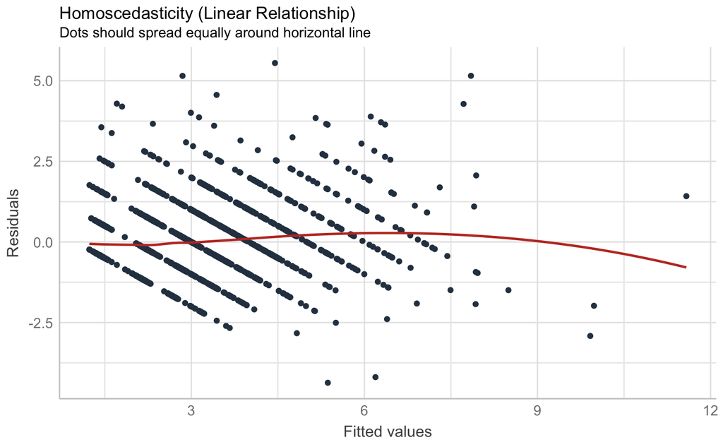

```r
x <- check_heteroscedasticity(m_growth)
plot(x)
```

## 5.2 Random effects

Plot:

```r
m_growth2 <- update(m_growth, .~. - (1|plot))
```

```
boundary (singular) fit: see ?isSingular
```

```r
AICtab(m_growth, m_growth2)
```

```
          dAIC df
m_growth2 0    8
m_growth  2    9
```

Plant ID:

```r
m_growth3 <- update(m_growth2, .~. - (1|ha_id_number))
```

```
boundary (singular) fit: see ?isSingular
```

```r
AICtab(m_growth2, m_growth3)
```

```
          dAIC df
m_growth2  0   8
m_growth3 41   7
```

Can’t remove plant ID

Year:

```r
m_growth4 <- update(m_growth2, .~. - (1|year_post))
AICtab(m_growth, m_growth2, m_growth3, m_growth4)
```

```
          dAIC df
m_growth4  0   7
m_growth2  2   8
m_growth   4   9
m_growth3 43   7
```

Can remove year

## 5.3 Does density matter beyond immediate surroundings?

```r
Anova(m_growth4)
```

```
Analysis of Deviance Table (Type II Wald chisquare tests)

Response: shts_next
               Chisq Df Pr(>Chisq)
log_shts   1224.8663  1     <2e-16 ***
habitat       0.0099  1     0.9206
shts_0_2.5    1.1966  1     0.2740
shts_2.5_5    0.0564  1     0.8122
---
Signif. codes:  0 ‘***’ 0.001 ‘**’ 0.01 ‘*’ 0.05 ‘.’ 0.1 ‘ ’ 1
```

```r
fixef(m_growth4)
```

```
(Intercept)    log_shts   habitatCF  shts_0_2.5  shts_2.5_5
0.368509413 0.636066676 0.001902743 0.020250677 0.007567832
```

- Just 5750: marginaly significant negative density dependence at 2.5–5m
- Only CF: no significant effect of density dependence
- Only 3-shoot plants: no significant effect of density dependence
- Full dataset: No density dependence

# 6 Survival

Pre-reproductive census, so plants live/die in same year as `shts` and `ht`

```r
m_surv <-
  glmer(
    surv ~
      log_shts +
      habitat +
      shts_0_2.5 + shts_2.5_5 +
      (1|ha_id_number) +
      (1|plot) +
      (1|year_post),
    family = binomial, data = ha_sub
  )
```

```
boundary (singular) fit: see ?isSingular
```

## 6.1 Random effects

Plot:

```r
m_surv2 <- update(m_surv, .~. - (1|plot))
```

```
boundary (singular) fit: see ?isSingular
```

```r
AICtab(m_surv, m_surv2)
```

```
        dAIC df
m_surv2 0    7
m_surv  2    8
```

Plant ID:

```r
m_surv3 <- update(m_surv2, .~. - (1|ha_id_number))
```

```
boundary (singular) fit: see ?isSingular
```

```r
AICtab(m_surv2, m_surv3)
```

```
        dAIC df
m_surv3 0    6
m_surv2 2    7
```

Close to equivalent, so remove plant ID. This makes sense, as plants only die once!

Year:

```r
m_surv4 <- glm(surv ~
                 log_shts +
                 habitat +
                 shts_0_2.5 + shts_2.5_5,
                family = binomial, data = ha_sub)
AICtab(m_surv4, m_surv3)
```

```
        dAIC df
m_surv4 0    5
m_surv3 2    6
```

glm is best

## 6.2 Density dependence?

```r
Anova(m_surv4)
```

```
Analysis of Deviance Table (Type II tests)

Response: surv
           LR Chisq Df Pr(>Chisq)
log_shts    147.800  1     <2e-16 ***
habitat       0.983  1     0.3214
shts_0_2.5    0.909  1     0.3405
shts_2.5_5    1.367  1     0.2423
---
Signif. codes:  0 ‘***’ 0.001 ‘**’ 0.01 ‘*’ 0.05 ‘.’ 0.1 ‘ ’ 1
```

```r
coef(m_surv4)
```

```
(Intercept)    log_shts   habitatCF  shts_0_2.5  shts_2.5_5
  2.1957676   1.8831378  -0.2311833   0.2150254  -0.4625155
```

- Just 5750: no density dependence
- Only CF: no density dependence
- Only 3-shoot plants: Marginally significant density dependence. Negative at 0–2.5m, positive at 2.5–5m
- Full dataset: no density dependence

# 7 Flowering probability

Make a binary column

```r
ha_sub <-
  ha_sub %>%
  mutate(flwr = as.integer(infl > 0), .before = infl)

unique(ha_sub$flwr)
```

```
[1] NA  1
```

Can’t do this model because no variation in flowering.

```r
m_flwr <-
  glmer(
    flwr ~ log_shts + habitat + shts_0_2.5 + shts_2.5_5 +
      (1|ha_id_number) + (1|year_post) + (1|habitat:plot),
    family = binomial, data = ha_sub
  )
```

# 8 Kernel approach

I’d like to take the approach in Teller et al. 2016, but the code is so convoluted that it is not adaptable. Instead, I’ll start by trying to adapt the `dlnm` approach.

## 8.1 Set up the crossbasis

```r
Q <-
  ha_sub %>%
  select(shts_0_0.5:shts_4.5_5) %>%
  as.matrix()

L <-
  matrix(seq(0.25, 4.75, by = 0.5), #use midpoint of r1 and r2
         nrow = nrow(Q),
         ncol = ncol(Q),
         byrow = TRUE)
```

```r
library(dlnm)
library(mgcv)
library(visibly) # better diagnostic visulazations.  one of several packages for this.
source(here("R", "utils.R"))
```

## 8.2 Growth

```r
g_growth <-
  gam(shts_next ~
        # s(ha_id_number, bs = "re") + #this takes waaay too long to converge
        s(plot, bs = "re") +
        log_shts + #when modeled as a spline, edf is essentially a line
        habitat +
        s(Q, L,
          bs = "cb",
          k = c(2,2),
          xt = list(bs = "cr")),
      family = gaussian(link = "log"),
      data = ha_sub,
      method = "REML")
```

```
basis dimension, k, increased to minimum possible
basis dimension, k, increased to minimum possible
```

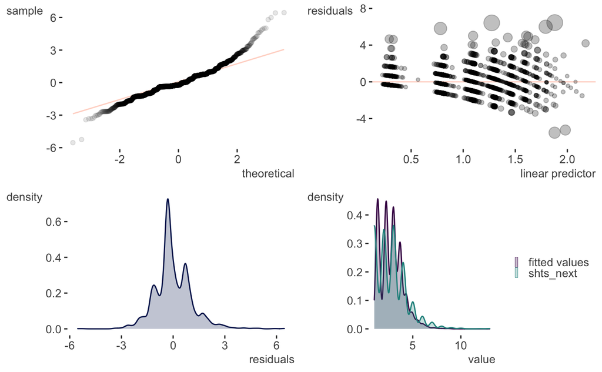

```r
plot_gam_check(g_growth)
```

```r
anova(g_growth)
```

```
Family: gaussian
Link function: log

Formula:
shts_next ~ s(plot, bs = "re") + log_shts + habitat + s(Q, L,
    bs = "cb", k = c(2, 2), xt = list(bs = "cr"))

Parametric Terms:
         df        F p-value
log_shts  1 3129.404  <2e-16
habitat   1    0.189   0.664

Approximate significance of smooth terms:
          edf Ref.df     F  p-value
s(plot) 1.180  8.000 0.192    0.243
s(Q,L)  4.682  4.948 6.226 1.66e-05
```

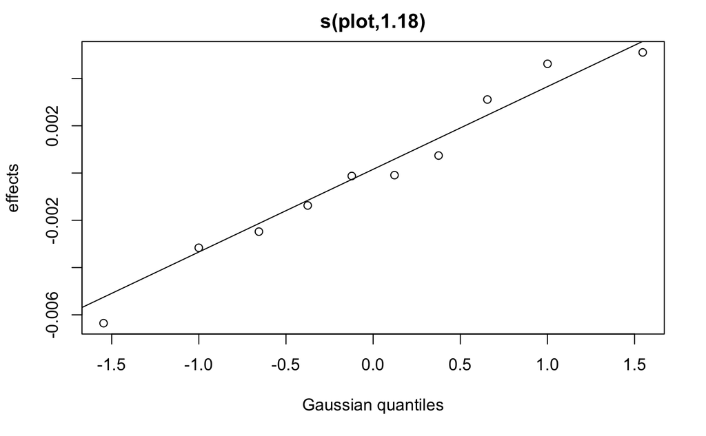

```r
plot(g_growth, pages = 1)
```

Effects of density:

```r
pred_growth <- pred_cb(Q, L, g_growth)
```

Which predicted values are too far from data to sensibly plot? (this is modeled after `mgcv::exclude.too.far`, which does not work for these models)

```r
dat <-
  ha_sub %>%
  select(shts_0.5_1:shts_4.5_5) %>%
  pivot_longer(everything(),
               names_prefix = "shts_",
               names_sep = "_",
               names_to = c("inner", "outer"),
               names_transform = list(inner = as.numeric, outer = as.numeric),
               values_to = "x") %>%
  mutate(lag = (inner + outer) / 2)


which.too.far <- function(grid, data, x, y, dist = 0.1) {
  x <- enquo(x)
  y <- enquo(y)
  # x <- quo(x)
  # y <- quo(lag)

  grid1 <-
    grid %>%
    mutate(min_g_x = min(!!x, na.rm = TRUE),
           min_g_y = min(!!y, na.rm = TRUE),
           g_x = !!x - min_g_x,
           g_y = !!y - min_g_y) %>%
    mutate(max_g_x = max(g_x, na.rm = TRUE),
           max_g_y = max(g_y, na.rm = TRUE),
           g_x = g_x / max_g_x,
           g_y = g_y / max_g_y)

  data1 <-
    data %>%
    mutate(d_x = (!!x - first(grid1$min_g_x)) / first(grid1$max_g_x),
           d_y = (!!y - first(grid1$min_g_y)) / first(grid1$max_g_y))


  if (dist < 0)
    stop("supplied dist negative")

  #where dat is a 2-column matrix of x and y coords of the true data used to build the model
  min_dist <- function(g_x, g_y, dat) {
    dat[,1] <- dat[,1] - g_x
    dat[,2] <- dat[,2] - g_y
    min(
      sqrt(
        (dat[,1]^2 + dat[,2]^2)
      ), na.rm = TRUE
    )
  }
  o <-
    grid1 %>%
    rowwise() %>%
    mutate(min_dist = min_dist(g_x, g_y, cbind(data1$d_x, data1$d_y)),
           too.far = min_dist > dist) %>%
    select(-g_x, -g_y, -max_g_x, -max_g_y, -min_g_x, -min_g_y)
  return(o)
}

pred_growth <- which.too.far(pred_growth, dat, x = x, y = lag)
```

[figure not shown]

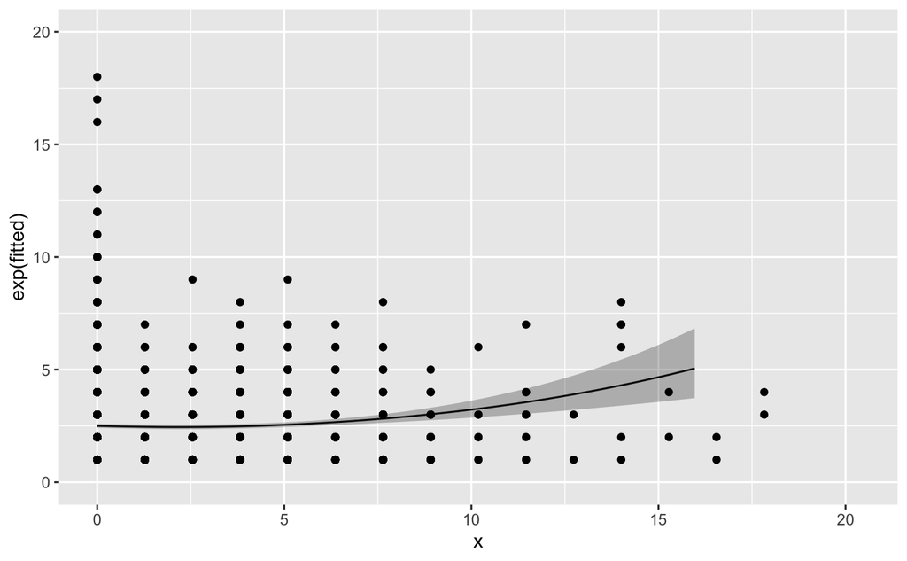

```r
pred_growth %>%
  filter(min_dist < 0.1) %>%
  filter(lag == 0.75) %>%
  ggplot(aes(x = x, y = exp(fitted), ymin = exp(fitted - 1.96*se.fit), ymax = exp(fitted + 1.96*se.fit))) +
  geom_line() +
  geom_ribbon(alpha = 0.3) +
  geom_point(data = ha_sub, aes(x = shts_0_0.5, y = shts_next), inherit.aes = FALSE) +
  coord_cartesian(ylim = c(0,20))
```

## 8.3 Survival

```r
g_surv <-
  gam(surv ~
        s(plot, bs = "re") +
        s(log_shts) +
        habitat +
        s(Q, L,
          bs = "cb",
          xt = list(bs = "cr")),
      family = binomial,
      data = ha_sub,
      method = "REML")
```

```r
# plot_gam_check(g_surv)
anova(g_surv)
```

[output not shown]

Effect of size on survival:

[output not shown]

[output cut: 990 more lines]

```r
pred_surv <- pred_cb(Q, L, g_surv)
ggplot(pred_surv, aes(x = x, y = lag, z = plogis(fitted), fill = plogis(fitted))) +
  geom_raster(interpolate = TRUE) +
  geom_contour(color = "grey50", size = 0.4) +
  scale_y_continuous("distance (m)", expand = c(0,0)) +
  scale_x_continuous("conspecific density (shoots/m^2)", expand = c(0,0)) +
  scale_fill_viridis_c("P(survival)", option = "A")
```

[output not shown]

- 5750 only: No significant density dependence
- CF only: Also not significant.
- 3-shoot plants only: no significant density dependence
- Full dataset: no significant effect of density dependence.